# Risk Factor Analysis

## Outcome Variable

**Outcome Variable:** ever_wasted

## Predictor Variables

**Intervention Variable:** hhwealth_quart

**Adjustment Set:**

- arm
- sex
- W_mage
- meducyrs
- feducyrs
- W_gagebrth
- W_birthwt
- W_birthlen
- W_nchldlt5
- W_parity
- delta_W_mage
- delta_meducyrs
- delta_feducyrs
- delta_W_gagebrth
- delta_W_birthwt
- delta_W_birthlen
- delta_W_nchldlt5
- delta_W_parity

## Stratifying Variables

The analysis was stratified on these variable(s):

- agecat
- studyid
- country

## Data Summary

| agecat | studyid | country | hhwealth_quart | ever_wasted | n_cell | n |
| --- | --- | --- | --- | --- | --- | --- |
| 0-24 months | ki0047075b-MAL-ED | BANGLADESH | Wealth Q4 | 0 | 17 | 82 |
| 0-24 months | ki0047075b-MAL-ED | BANGLADESH | Wealth Q4 | 1 | 4 | 82 |
| 0-24 months | ki0047075b-MAL-ED | BANGLADESH | Wealth Q1 | 0 | 11 | 82 |
| 0-24 months | ki0047075b-MAL-ED | BANGLADESH | Wealth Q1 | 1 | 10 | 82 |
| 0-24 months | ki0047075b-MAL-ED | BANGLADESH | Wealth Q2 | 0 | 9 | 82 |
| 0-24 months | ki0047075b-MAL-ED | BANGLADESH | Wealth Q2 | 1 | 11 | 82 |
| 0-24 months | ki0047075b-MAL-ED | BANGLADESH | Wealth Q3 | 0 | 15 | 82 |
| 0-24 months | ki0047075b-MAL-ED | BANGLADESH | Wealth Q3 | 1 | 5 | 82 |
| 0-24 months | ki0047075b-MAL-ED | INDIA | Wealth Q4 | 0 | 8 | 71 |
| 0-24 months | ki0047075b-MAL-ED | INDIA | Wealth Q4 | 1 | 10 | 71 |
| 0-24 months | ki0047075b-MAL-ED | INDIA | Wealth Q1 | 0 | 7 | 71 |
| 0-24 months | ki0047075b-MAL-ED | INDIA | Wealth Q1 | 1 | 12 | 71 |
| 0-24 months | ki0047075b-MAL-ED | INDIA | Wealth Q2 | 0 | 10 | 71 |
| 0-24 months | ki0047075b-MAL-ED | INDIA | Wealth Q2 | 1 | 7 | 71 |
| 0-24 months | ki0047075b-MAL-ED | INDIA | Wealth Q3 | 0 | 7 | 71 |
| 0-24 months | ki0047075b-MAL-ED | INDIA | Wealth Q3 | 1 | 10 | 71 |
| 0-24 months | ki0047075b-MAL-ED | NEPAL | Wealth Q4 | 0 | 10 | 42 |
| 0-24 months | ki0047075b-MAL-ED | NEPAL | Wealth Q4 | 1 | 1 | 42 |
| 0-24 months | ki0047075b-MAL-ED | NEPAL | Wealth Q1 | 0 | 7 | 42 |
| 0-24 months | ki0047075b-MAL-ED | NEPAL | Wealth Q1 | 1 | 4 | 42 |
| 0-24 months | ki0047075b-MAL-ED | NEPAL | Wealth Q2 | 0 | 8 | 42 |
| 0-24 months | ki0047075b-MAL-ED | NEPAL | Wealth Q2 | 1 | 2 | 42 |
| 0-24 months | ki0047075b-MAL-ED | NEPAL | Wealth Q3 | 0 | 7 | 42 |
| 0-24 months | ki0047075b-MAL-ED | NEPAL | Wealth Q3 | 1 | 3 | 42 |
| 0-24 months | ki0047075b-MAL-ED | PERU | Wealth Q4 | 0 | 8 | 37 |
| 0-24 months | ki0047075b-MAL-ED | PERU | Wealth Q4 | 1 | 2 | 37 |
| 0-24 months | ki0047075b-MAL-ED | PERU | Wealth Q1 | 0 | 8 | 37 |
| 0-24 months | ki0047075b-MAL-ED | PERU | Wealth Q1 | 1 | 1 | 37 |
| 0-24 months | ki0047075b-MAL-ED | PERU | Wealth Q2 | 0 | 7 | 37 |
| 0-24 months | ki0047075b-MAL-ED | PERU | Wealth Q2 | 1 | 2 | 37 |

[output cut: 378 more lines]

The following strata were considered:

- agecat: 0-24 months, studyid: ki0047075b-MAL-ED, country: BANGLADESH
- agecat: 0-24 months, studyid: ki0047075b-MAL-ED, country: INDIA
- agecat: 0-24 months, studyid: ki0047075b-MAL-ED, country: NEPAL
- agecat: 0-24 months, studyid: ki0047075b-MAL-ED, country: PERU
- agecat: 0-24 months, studyid: ki0047075b-MAL-ED, country: SOUTH AFRICA
- agecat: 0-24 months, studyid: ki0047075b-MAL-ED, country: TANZANIA, UNITED REPUBLIC OF
- agecat: 0-24 months, studyid: ki1000108-CMC-V-BCS-2002, country: INDIA
- agecat: 0-24 months, studyid: ki1000108-IRC, country: INDIA
- agecat: 0-24 months, studyid: ki1017093b-PROVIDE, country: BANGLADESH
- agecat: 0-24 months, studyid: ki1066203-TanzaniaChild2, country: TANZANIA, UNITED REPUBLIC OF
- agecat: 0-24 months, studyid: ki1113344-GMS-Nepal, country: NEPAL
- agecat: 0-24 months, studyid: ki1114097-CONTENT, country: PERU
- agecat: 0-24 months, studyid: ki1135781-COHORTS, country: GUATEMALA
- agecat: 0-24 months, studyid: ki1135781-COHORTS, country: PHILIPPINES
- agecat: 0-24 months, studyid: ki1148112-LCNI-5, country: MALAWI
- agecat: 0-24 months, studyid: kiGH5241-JiVitA-3, country: BANGLADESH
- agecat: 0-24 months, studyid: kiGH5241-JiVitA-4, country: BANGLADESH
- agecat: 0-6 months, studyid: ki0047075b-MAL-ED, country: BANGLADESH
- agecat: 0-6 months, studyid: ki0047075b-MAL-ED, country: INDIA
- agecat: 0-6 months, studyid: ki0047075b-MAL-ED, country: NEPAL
- agecat: 0-6 months, studyid: ki0047075b-MAL-ED, country: PERU
- agecat: 0-6 months, studyid: ki0047075b-MAL-ED, country: SOUTH AFRICA
- agecat: 0-6 months, studyid: ki0047075b-MAL-ED, country: TANZANIA, UNITED REPUBLIC OF
- agecat: 0-6 months, studyid: ki1000108-CMC-V-BCS-2002, country: INDIA
- agecat: 0-6 months, studyid: ki1000108-IRC, country: INDIA
- agecat: 0-6 months, studyid: ki1017093b-PROVIDE, country: BANGLADESH
- agecat: 0-6 months, studyid: ki1066203-TanzaniaChild2, country: TANZANIA, UNITED REPUBLIC OF
- agecat: 0-6 months, studyid: ki1113344-GMS-Nepal, country: NEPAL
- agecat: 0-6 months, studyid: ki1114097-CONTENT, country: PERU
- agecat: 0-6 months, studyid: ki1135781-COHORTS, country: GUATEMALA
- agecat: 0-6 months, studyid: ki1135781-COHORTS, country: PHILIPPINES
- agecat: 0-6 months, studyid: ki1148112-LCNI-5, country: MALAWI
- agecat: 0-6 months, studyid: kiGH5241-JiVitA-3, country: BANGLADESH
- agecat: 0-6 months, studyid: kiGH5241-JiVitA-4, country: BANGLADESH
- agecat: 6-24 months, studyid: ki0047075b-MAL-ED, country: BANGLADESH
- agecat: 6-24 months, studyid: ki0047075b-MAL-ED, country: INDIA
- agecat: 6-24 months, studyid: ki0047075b-MAL-ED, country: NEPAL
- agecat: 6-24 months, studyid: ki0047075b-MAL-ED, country: PERU
- agecat: 6-24 months, studyid: ki0047075b-MAL-ED, country: SOUTH AFRICA
- agecat: 6-24 months, studyid: ki0047075b-MAL-ED, country: TANZANIA, UNITED REPUBLIC OF
- agecat: 6-24 months, studyid: ki1000108-CMC-V-BCS-2002, country: INDIA
- agecat: 6-24 months, studyid: ki1000108-IRC, country: INDIA
- agecat: 6-24 months, studyid: ki1017093b-PROVIDE, country: BANGLADESH
- agecat: 6-24 months, studyid: ki1066203-TanzaniaChild2, country: TANZANIA, UNITED REPUBLIC OF
- agecat: 6-24 months, studyid: ki1113344-GMS-Nepal, country: NEPAL
- agecat: 6-24 months, studyid: ki1114097-CONTENT, country: PERU
- agecat: 6-24 months, studyid: ki1135781-COHORTS, country: GUATEMALA
- agecat: 6-24 months, studyid: ki1135781-COHORTS, country: PHILIPPINES
- agecat: 6-24 months, studyid: ki1148112-LCNI-5, country: MALAWI
- agecat: 6-24 months, studyid: kiGH5241-JiVitA-3, country: BANGLADESH
- agecat: 6-24 months, studyid: kiGH5241-JiVitA-4, country: BANGLADESH

### Dropped Strata

Some strata were dropped due to rare outcomes:

- agecat: 0-24 months, studyid: ki0047075b-MAL-ED, country: BANGLADESH
- agecat: 0-24 months, studyid: ki0047075b-MAL-ED, country: NEPAL
- agecat: 0-24 months, studyid: ki0047075b-MAL-ED, country: PERU
- agecat: 0-24 months, studyid: ki0047075b-MAL-ED, country: SOUTH AFRICA
- agecat: 0-24 months, studyid: ki0047075b-MAL-ED, country: TANZANIA, UNITED REPUBLIC OF
- agecat: 0-24 months, studyid: ki1114097-CONTENT, country: PERU
- agecat: 0-6 months, studyid: ki0047075b-MAL-ED, country: BANGLADESH
- agecat: 0-6 months, studyid: ki0047075b-MAL-ED, country: NEPAL
- agecat: 0-6 months, studyid: ki0047075b-MAL-ED, country: PERU
- agecat: 0-6 months, studyid: ki0047075b-MAL-ED, country: SOUTH AFRICA
- agecat: 0-6 months, studyid: ki0047075b-MAL-ED, country: TANZANIA, UNITED REPUBLIC OF
- agecat: 0-6 months, studyid: ki1114097-CONTENT, country: PERU
- agecat: 0-6 months, studyid: ki1148112-LCNI-5, country: MALAWI
- agecat: 6-24 months, studyid: ki0047075b-MAL-ED, country: BANGLADESH
- agecat: 6-24 months, studyid: ki0047075b-MAL-ED, country: INDIA
- agecat: 6-24 months, studyid: ki0047075b-MAL-ED, country: NEPAL
- agecat: 6-24 months, studyid: ki0047075b-MAL-ED, country: PERU
- agecat: 6-24 months, studyid: ki0047075b-MAL-ED, country: SOUTH AFRICA
- agecat: 6-24 months, studyid: ki0047075b-MAL-ED, country: TANZANIA, UNITED REPUBLIC OF
- agecat: 6-24 months, studyid: ki1114097-CONTENT, country: PERU

## Methods Detail

We’re interested in the causal parameters $E[Y_a]$ for all values of $a \in \mathcal{A}$. These parameters represent the mean outcome if, possibly contrary to fact, we intervened to set all units to have $A=a$. Under the randomization and positivity assumptions, these are identified by the statistical parameters $\psi_a=E_W[E_{Y|A,W}(Y|A=a,W)]$. In addition, we’re interested in the mean of $Y$, $E[Y]$ under no intervention (the observed mean). We will estimate these parameters by using SuperLearner to fit the relevant likelihood factors – $E_{Y|A,W}(Y|A=a,W)$ and $p(A=a|W)$, and then updating our likelihood fit using a joint TMLE.

For unadjusted analyses ($W=\{\}$), initial likelihoods were estimated using Lrnr_glm to estimate the simple $E(Y|A)$ and Lrnr_mean to estimate $p(A)$. For adjusted analyses, a small library containing Lrnr_glmnet, Lrnr_xgboost, and Lrnr_mean was used.

Having estimated these parameters, we will then use the delta method to estimate relative risks and attributable risks relative to a prespecified baseline level of $A$.

# Results Detail

## Results Plots

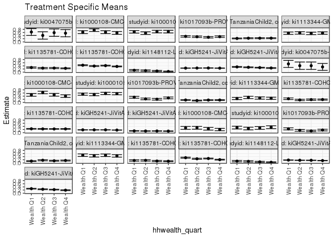

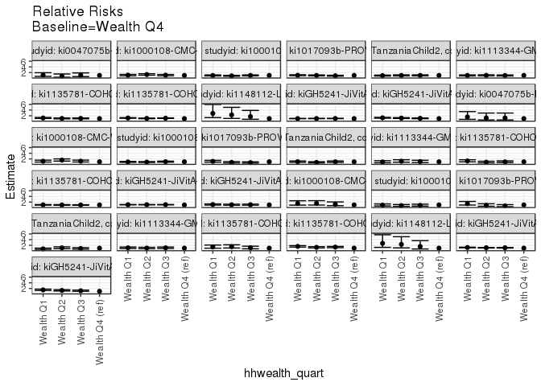

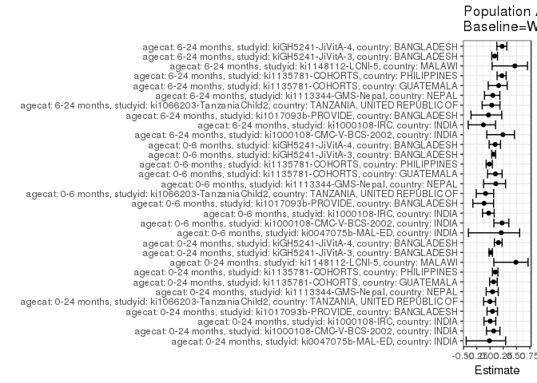

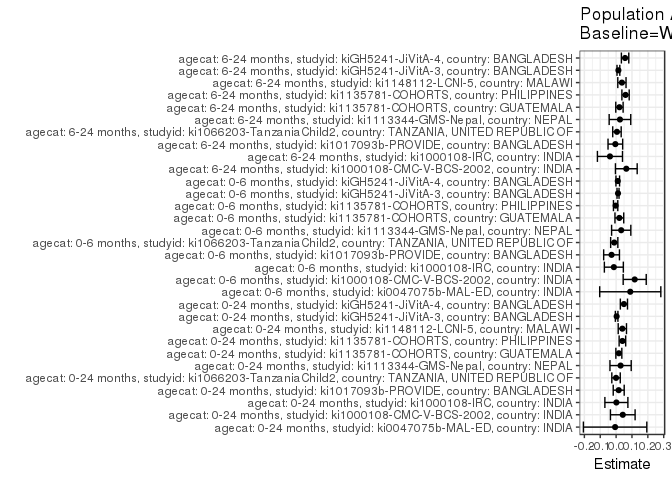

## Results Table

### Parameter: TSM

| agecat | studyid | country | intervention_level | baseline_level | estimate | ci_lower | ci_upper |
| --- | --- | --- | --- | --- | --- | --- | --- |
| 0-24 months | ki0047075b-MAL-ED | INDIA | Wealth Q4 | NA | 0.5555556 | 0.3243680 | 0.7867431 |
| 0-24 months | ki0047075b-MAL-ED | INDIA | Wealth Q1 | NA | 0.6315789 | 0.4131363 | 0.8500216 |
| 0-24 months | ki0047075b-MAL-ED | INDIA | Wealth Q2 | NA | 0.4117647 | 0.1761492 | 0.6473802 |
| 0-24 months | ki0047075b-MAL-ED | INDIA | Wealth Q3 | NA | 0.5882353 | 0.3526198 | 0.8238508 |
| 0-24 months | ki1000108-CMC-V-BCS-2002 | INDIA | Wealth Q4 | NA | 0.5719329 | 0.4804311 | 0.6634348 |
| 0-24 months | ki1000108-CMC-V-BCS-2002 | INDIA | Wealth Q1 | NA | 0.6229364 | 0.5293790 | 0.7164937 |
| 0-24 months | ki1000108-CMC-V-BCS-2002 | INDIA | Wealth Q2 | NA | 0.7493435 | 0.6663341 | 0.8323529 |
| 0-24 months | ki1000108-CMC-V-BCS-2002 | INDIA | Wealth Q3 | NA | 0.6211914 | 0.5285367 | 0.7138460 |
| 0-24 months | ki1000108-IRC | INDIA | Wealth Q4 | NA | 0.6543673 | 0.5699854 | 0.7387492 |
| 0-24 months | ki1000108-IRC | INDIA | Wealth Q1 | NA | 0.6432125 | 0.5633103 | 0.7231148 |
| 0-24 months | ki1000108-IRC | INDIA | Wealth Q2 | NA | 0.5581302 | 0.4741082 | 0.6421522 |
| 0-24 months | ki1000108-IRC | INDIA | Wealth Q3 | NA | 0.6559127 | 0.5735945 | 0.7382310 |
| 0-24 months | ki1017093b-PROVIDE | BANGLADESH | Wealth Q4 | NA | 0.3345824 | 0.2869985 | 0.3821663 |
| 0-24 months | ki1017093b-PROVIDE | BANGLADESH | Wealth Q1 | NA | 0.3523328 | 0.3036487 | 0.4010169 |
| 0-24 months | ki1017093b-PROVIDE | BANGLADESH | Wealth Q2 | NA | 0.3301511 | 0.2840412 | 0.3762610 |
| 0-24 months | ki1017093b-PROVIDE | BANGLADESH | Wealth Q3 | NA | 0.2958214 | 0.2506750 | 0.3409679 |
| 0-24 months | ki1066203-TanzaniaChild2 | TANZANIA, UNITED REPUBLIC OF | Wealth Q4 | NA | 0.2370269 | 0.2060856 | 0.2679682 |
| 0-24 months | ki1066203-TanzaniaChild2 | TANZANIA, UNITED REPUBLIC OF | Wealth Q1 | NA | 0.2206879 | 0.1924645 | 0.2489113 |
| 0-24 months | ki1066203-TanzaniaChild2 | TANZANIA, UNITED REPUBLIC OF | Wealth Q2 | NA | 0.2352970 | 0.2010632 | 0.2695307 |
| 0-24 months | ki1066203-TanzaniaChild2 | TANZANIA, UNITED REPUBLIC OF | Wealth Q3 | NA | 0.2365244 | 0.2047492 | 0.2682996 |
| 0-24 months | ki1113344-GMS-Nepal | NEPAL | Wealth Q4 | NA | 0.5631287 | 0.4858628 | 0.6403946 |
| 0-24 months | ki1113344-GMS-Nepal | NEPAL | Wealth Q1 | NA | 0.5554463 | 0.4784551 | 0.6324374 |
| 0-24 months | ki1113344-GMS-Nepal | NEPAL | Wealth Q2 | NA | 0.5733904 | 0.4954815 | 0.6512993 |
| 0-24 months | ki1113344-GMS-Nepal | NEPAL | Wealth Q3 | NA | 0.5443087 | 0.4658281 | 0.6227892 |
| 0-24 months | ki1135781-COHORTS | GUATEMALA | Wealth Q4 | NA | 0.2440269 | 0.2152419 | 0.2728119 |
| 0-24 months | ki1135781-COHORTS | GUATEMALA | Wealth Q1 | NA | 0.2942324 | 0.2551950 | 0.3332699 |
| 0-24 months | ki1135781-COHORTS | GUATEMALA | Wealth Q2 | NA | 0.2556518 | 0.2185109 | 0.2927927 |
| 0-24 months | ki1135781-COHORTS | GUATEMALA | Wealth Q3 | NA | 0.2604593 | 0.2248457 | 0.2960729 |
| 0-24 months | ki1135781-COHORTS | PHILIPPINES | Wealth Q4 | NA | 0.3640185 | 0.3383041 | 0.3897329 |
| 0-24 months | ki1135781-COHORTS | PHILIPPINES | Wealth Q1 | NA | 0.4422708 | 0.4126942 | 0.4718474 |

[output cut: 94 more lines]

### Parameter: E(Y)

| agecat | studyid | country | intervention_level | baseline_level | estimate | ci_lower | ci_upper |
| --- | --- | --- | --- | --- | --- | --- | --- |
| 0-24 months | ki0047075b-MAL-ED | INDIA | NA | NA | 0.5492958 | 0.4327362 | 0.6658554 |
| 0-24 months | ki1000108-CMC-V-BCS-2002 | INDIA | NA | NA | 0.6139410 | 0.5644682 | 0.6634139 |
| 0-24 months | ki1000108-IRC | INDIA | NA | NA | 0.6560976 | 0.6100625 | 0.7021326 |
| 0-24 months | ki1017093b-PROVIDE | BANGLADESH | NA | NA | 0.3510029 | 0.3155698 | 0.3864359 |
| 0-24 months | ki1066203-TanzaniaChild2 | TANZANIA, UNITED REPUBLIC OF | NA | NA | 0.2365772 | 0.2195142 | 0.2536402 |
| 0-24 months | ki1113344-GMS-Nepal | NEPAL | NA | NA | 0.5913621 | 0.5520608 | 0.6306634 |
| 0-24 months | ki1135781-COHORTS | GUATEMALA | NA | NA | 0.2612827 | 0.2370438 | 0.2855216 |
| 0-24 months | ki1135781-COHORTS | PHILIPPINES | NA | NA | 0.4037451 | 0.3863123 | 0.4211779 |
| 0-24 months | ki1148112-LCNI-5 | MALAWI | NA | NA | 0.0807834 | 0.0620863 | 0.0994804 |
| 0-24 months | kiGH5241-JiVitA-3 | BANGLADESH | NA | NA | 0.2582228 | 0.2517573 | 0.2646883 |
| 0-24 months | kiGH5241-JiVitA-4 | BANGLADESH | NA | NA | 0.3126363 | 0.2981271 | 0.3271455 |
| 0-6 months | ki0047075b-MAL-ED | INDIA | NA | NA | 0.4225352 | 0.3068192 | 0.5382512 |
| 0-6 months | ki1000108-CMC-V-BCS-2002 | INDIA | NA | NA | 0.5190217 | 0.4679041 | 0.5701394 |
| 0-6 months | ki1000108-IRC | INDIA | NA | NA | 0.5439024 | 0.4956326 | 0.5921723 |
| 0-6 months | ki1017093b-PROVIDE | BANGLADESH | NA | NA | 0.2578797 | 0.2254025 | 0.2903568 |
| 0-6 months | ki1066203-TanzaniaChild2 | TANZANIA, UNITED REPUBLIC OF | NA | NA | 0.1392617 | 0.1253610 | 0.1531625 |
| 0-6 months | ki1113344-GMS-Nepal | NEPAL | NA | NA | 0.2956811 | 0.2591967 | 0.3321655 |
| 0-6 months | ki1135781-COHORTS | GUATEMALA | NA | NA | 0.2029557 | 0.1782002 | 0.2277111 |
| 0-6 months | ki1135781-COHORTS | PHILIPPINES | NA | NA | 0.2356227 | 0.2205417 | 0.2507038 |
| 0-6 months | kiGH5241-JiVitA-3 | BANGLADESH | NA | NA | 0.1763106 | 0.1706836 | 0.1819376 |
| 0-6 months | kiGH5241-JiVitA-4 | BANGLADESH | NA | NA | 0.1078103 | 0.0979894 | 0.1176312 |
| 6-24 months | ki1000108-CMC-V-BCS-2002 | INDIA | NA | NA | 0.2654155 | 0.2205451 | 0.3102860 |
| 6-24 months | ki1000108-IRC | INDIA | NA | NA | 0.3097561 | 0.2649438 | 0.3545684 |
| 6-24 months | ki1017093b-PROVIDE | BANGLADESH | NA | NA | 0.1615008 | 0.1323460 | 0.1906557 |
| 6-24 months | ki1066203-TanzaniaChild2 | TANZANIA, UNITED REPUBLIC OF | NA | NA | 0.1606965 | 0.1446374 | 0.1767556 |
| 6-24 months | ki1113344-GMS-Nepal | NEPAL | NA | NA | 0.4728814 | 0.4325613 | 0.5132014 |
| 6-24 months | ki1135781-COHORTS | GUATEMALA | NA | NA | 0.1291161 | 0.1097606 | 0.1484716 |
| 6-24 months | ki1135781-COHORTS | PHILIPPINES | NA | NA | 0.2666429 | 0.2502871 | 0.2829988 |
| 6-24 months | ki1148112-LCNI-5 | MALAWI | NA | NA | 0.0782609 | 0.0596958 | 0.0968259 |
| 6-24 months | kiGH5241-JiVitA-3 | BANGLADESH | NA | NA | 0.1639050 | 0.1577770 | 0.1700330 |
| 6-24 months | kiGH5241-JiVitA-4 | BANGLADESH | NA | NA | 0.2479841 | 0.2343635 | 0.2616046 |

### Parameter: RR

| agecat | studyid | country | intervention_level | baseline_level | estimate | ci_lower | ci_upper |
| --- | --- | --- | --- | --- | --- | --- | --- |
| 0-24 months | ki0047075b-MAL-ED | INDIA | Wealth Q4 | Wealth Q4 | 1.0000000 | 1.0000000 | 1.0000000 |
| 0-24 months | ki0047075b-MAL-ED | INDIA | Wealth Q1 | Wealth Q4 | 1.1368421 | 0.6617609 | 1.9529862 |
| 0-24 months | ki0047075b-MAL-ED | INDIA | Wealth Q2 | Wealth Q4 | 0.7411765 | 0.3652975 | 1.5038222 |
| 0-24 months | ki0047075b-MAL-ED | INDIA | Wealth Q3 | Wealth Q4 | 1.0588235 | 0.5942652 | 1.8865437 |
| 0-24 months | ki1000108-CMC-V-BCS-2002 | INDIA | Wealth Q4 | Wealth Q4 | 1.0000000 | 1.0000000 | 1.0000000 |
| 0-24 months | ki1000108-CMC-V-BCS-2002 | INDIA | Wealth Q1 | Wealth Q4 | 1.0891773 | 0.8757575 | 1.3546069 |
| 0-24 months | ki1000108-CMC-V-BCS-2002 | INDIA | Wealth Q2 | Wealth Q4 | 1.3101947 | 1.0803579 | 1.5889274 |
| 0-24 months | ki1000108-CMC-V-BCS-2002 | INDIA | Wealth Q3 | Wealth Q4 | 1.0861262 | 0.8742984 | 1.3492764 |
| 0-24 months | ki1000108-IRC | INDIA | Wealth Q4 | Wealth Q4 | 1.0000000 | 1.0000000 | 1.0000000 |
| 0-24 months | ki1000108-IRC | INDIA | Wealth Q1 | Wealth Q4 | 0.9829533 | 0.8243197 | 1.1721147 |
| 0-24 months | ki1000108-IRC | INDIA | Wealth Q2 | Wealth Q4 | 0.8529311 | 0.7021328 | 1.0361167 |
| 0-24 months | ki1000108-IRC | INDIA | Wealth Q3 | Wealth Q4 | 1.0023617 | 0.8395342 | 1.1967696 |
| 0-24 months | ki1017093b-PROVIDE | BANGLADESH | Wealth Q4 | Wealth Q4 | 1.0000000 | 1.0000000 | 1.0000000 |
| 0-24 months | ki1017093b-PROVIDE | BANGLADESH | Wealth Q1 | Wealth Q4 | 1.0530524 | 0.8929541 | 1.2418550 |
| 0-24 months | ki1017093b-PROVIDE | BANGLADESH | Wealth Q2 | Wealth Q4 | 0.9867558 | 0.8368242 | 1.1635502 |
| 0-24 months | ki1017093b-PROVIDE | BANGLADESH | Wealth Q3 | Wealth Q4 | 0.8841512 | 0.7448590 | 1.0494917 |
| 0-24 months | ki1066203-TanzaniaChild2 | TANZANIA, UNITED REPUBLIC OF | Wealth Q4 | Wealth Q4 | 1.0000000 | 1.0000000 | 1.0000000 |
| 0-24 months | ki1066203-TanzaniaChild2 | TANZANIA, UNITED REPUBLIC OF | Wealth Q1 | Wealth Q4 | 0.9310670 | 0.7769786 | 1.1157139 |
| 0-24 months | ki1066203-TanzaniaChild2 | TANZANIA, UNITED REPUBLIC OF | Wealth Q2 | Wealth Q4 | 0.9927016 | 0.8178339 | 1.2049592 |
| 0-24 months | ki1066203-TanzaniaChild2 | TANZANIA, UNITED REPUBLIC OF | Wealth Q3 | Wealth Q4 | 0.9978801 | 0.8286010 | 1.2017421 |
| 0-24 months | ki1113344-GMS-Nepal | NEPAL | Wealth Q4 | Wealth Q4 | 1.0000000 | 1.0000000 | 1.0000000 |
| 0-24 months | ki1113344-GMS-Nepal | NEPAL | Wealth Q1 | Wealth Q4 | 0.9863576 | 0.8114229 | 1.1990066 |
| 0-24 months | ki1113344-GMS-Nepal | NEPAL | Wealth Q2 | Wealth Q4 | 1.0182226 | 0.8393417 | 1.2352266 |
| 0-24 months | ki1113344-GMS-Nepal | NEPAL | Wealth Q3 | Wealth Q4 | 0.9665795 | 0.7920750 | 1.1795297 |
| 0-24 months | ki1135781-COHORTS | GUATEMALA | Wealth Q4 | Wealth Q4 | 1.0000000 | 1.0000000 | 1.0000000 |
| 0-24 months | ki1135781-COHORTS | GUATEMALA | Wealth Q1 | Wealth Q4 | 1.2057376 | 1.0386189 | 1.3997465 |
| 0-24 months | ki1135781-COHORTS | GUATEMALA | Wealth Q2 | Wealth Q4 | 1.0476376 | 0.8945096 | 1.2269791 |
| 0-24 months | ki1135781-COHORTS | GUATEMALA | Wealth Q3 | Wealth Q4 | 1.0673384 | 0.9197902 | 1.2385556 |
| 0-24 months | ki1135781-COHORTS | PHILIPPINES | Wealth Q4 | Wealth Q4 | 1.0000000 | 1.0000000 | 1.0000000 |
| 0-24 months | ki1135781-COHORTS | PHILIPPINES | Wealth Q1 | Wealth Q4 | 1.2149679 | 1.1096860 | 1.3302385 |

[output cut: 94 more lines]

### Parameter: PAR

| agecat | studyid | country | intervention_level | baseline_level | estimate | ci_lower | ci_upper |
| --- | --- | --- | --- | --- | --- | --- | --- |
| 0-24 months | ki0047075b-MAL-ED | INDIA | Wealth Q4 | NA | -0.0062598 | -0.2060937 | 0.1935741 |
| 0-24 months | ki1000108-CMC-V-BCS-2002 | INDIA | Wealth Q4 | NA | 0.0420081 | -0.0356928 | 0.1197090 |
| 0-24 months | ki1000108-IRC | INDIA | Wealth Q4 | NA | 0.0017303 | -0.0707552 | 0.0742157 |
| 0-24 months | ki1017093b-PROVIDE | BANGLADESH | Wealth Q4 | NA | 0.0164205 | -0.0181524 | 0.0509933 |
| 0-24 months | ki1066203-TanzaniaChild2 | TANZANIA, UNITED REPUBLIC OF | Wealth Q4 | NA | -0.0004497 | -0.0270203 | 0.0261209 |
| 0-24 months | ki1113344-GMS-Nepal | NEPAL | Wealth Q4 | NA | 0.0282334 | -0.0387388 | 0.0952057 |
| 0-24 months | ki1135781-COHORTS | GUATEMALA | Wealth Q4 | NA | 0.0172557 | -0.0015718 | 0.0360833 |
| 0-24 months | ki1135781-COHORTS | PHILIPPINES | Wealth Q4 | NA | 0.0397266 | 0.0190188 | 0.0604344 |
| 0-24 months | ki1148112-LCNI-5 | MALAWI | Wealth Q4 | NA | 0.0393087 | 0.0132339 | 0.0653835 |
| 0-24 months | kiGH5241-JiVitA-3 | BANGLADESH | Wealth Q4 | NA | 0.0033308 | -0.0047672 | 0.0114289 |
| 0-24 months | kiGH5241-JiVitA-4 | BANGLADESH | Wealth Q4 | NA | 0.0492627 | 0.0266953 | 0.0718302 |
| 0-6 months | ki0047075b-MAL-ED | INDIA | Wealth Q4 | NA | 0.0892019 | -0.1034192 | 0.2818230 |
| 0-6 months | ki1000108-CMC-V-BCS-2002 | INDIA | Wealth Q4 | NA | 0.1171862 | 0.0445401 | 0.1898322 |
| 0-6 months | ki1000108-IRC | INDIA | Wealth Q4 | NA | -0.0142180 | -0.0740146 | 0.0455786 |
| 0-6 months | ki1017093b-PROVIDE | BANGLADESH | Wealth Q4 | NA | -0.0286426 | -0.0783815 | 0.0210964 |
| 0-6 months | ki1066203-TanzaniaChild2 | TANZANIA, UNITED REPUBLIC OF | Wealth Q4 | NA | -0.0117206 | -0.0343964 | 0.0109552 |
| 0-6 months | ki1113344-GMS-Nepal | NEPAL | Wealth Q4 | NA | 0.0321708 | -0.0284170 | 0.0927587 |
| 0-6 months | ki1135781-COHORTS | GUATEMALA | Wealth Q4 | NA | 0.0204207 | -0.0072296 | 0.0480710 |
| 0-6 months | ki1135781-COHORTS | PHILIPPINES | Wealth Q4 | NA | -0.0030361 | -0.0166560 | 0.0105838 |
| 0-6 months | kiGH5241-JiVitA-3 | BANGLADESH | Wealth Q4 | NA | 0.0121029 | 0.0058180 | 0.0183878 |
| 0-6 months | kiGH5241-JiVitA-4 | BANGLADESH | Wealth Q4 | NA | 0.0103895 | -0.0010332 | 0.0218123 |
| 6-24 months | ki1000108-CMC-V-BCS-2002 | INDIA | Wealth Q4 | NA | 0.0643371 | -0.0041452 | 0.1328194 |
| 6-24 months | ki1000108-IRC | INDIA | Wealth Q4 | NA | -0.0387342 | -0.1177780 | 0.0403096 |
| 6-24 months | ki1017093b-PROVIDE | BANGLADESH | Wealth Q4 | NA | -0.0047638 | -0.0508804 | 0.0413529 |
| 6-24 months | ki1066203-TanzaniaChild2 | TANZANIA, UNITED REPUBLIC OF | Wealth Q4 | NA | 0.0053180 | -0.0213661 | 0.0320022 |
| 6-24 months | ki1113344-GMS-Nepal | NEPAL | Wealth Q4 | NA | 0.0242373 | -0.0437853 | 0.0922600 |
| 6-24 months | ki1135781-COHORTS | GUATEMALA | Wealth Q4 | NA | 0.0210111 | -0.0020942 | 0.0441164 |
| 6-24 months | ki1135781-COHORTS | PHILIPPINES | Wealth Q4 | NA | 0.0594914 | 0.0365060 | 0.0824767 |
| 6-24 months | ki1148112-LCNI-5 | MALAWI | Wealth Q4 | NA | 0.0365942 | 0.0106304 | 0.0625580 |
| 6-24 months | kiGH5241-JiVitA-3 | BANGLADESH | Wealth Q4 | NA | 0.0145219 | 0.0056963 | 0.0233475 |
| 6-24 months | kiGH5241-JiVitA-4 | BANGLADESH | Wealth Q4 | NA | 0.0565991 | 0.0332784 | 0.0799199 |

### Parameter: PAF

| agecat | studyid | country | intervention_level | baseline_level | estimate | ci_lower | ci_upper |
| --- | --- | --- | --- | --- | --- | --- | --- |
| 0-24 months | ki0047075b-MAL-ED | INDIA | Wealth Q4 | NA | -0.0113960 | -0.4492472 | 0.2941702 |
| 0-24 months | ki1000108-CMC-V-BCS-2002 | INDIA | Wealth Q4 | NA | 0.0684237 | -0.0671824 | 0.1867983 |
| 0-24 months | ki1000108-IRC | INDIA | Wealth Q4 | NA | 0.0026372 | -0.1141862 | 0.1072115 |
| 0-24 months | ki1017093b-PROVIDE | BANGLADESH | Wealth Q4 | NA | 0.0467816 | -0.0567111 | 0.1401383 |
| 0-24 months | ki1066203-TanzaniaChild2 | TANZANIA, UNITED REPUBLIC OF | Wealth Q4 | NA | -0.0019008 | -0.1207574 | 0.1043510 |
| 0-24 months | ki1113344-GMS-Nepal | NEPAL | Wealth Q4 | NA | 0.0477431 | -0.0725267 | 0.1545261 |
| 0-24 months | ki1135781-COHORTS | GUATEMALA | Wealth Q4 | NA | 0.0660424 | -0.0083257 | 0.1349255 |
| 0-24 months | ki1135781-COHORTS | PHILIPPINES | Wealth Q4 | NA | 0.0983952 | 0.0458786 | 0.1480212 |
| 0-24 months | ki1148112-LCNI-5 | MALAWI | Wealth Q4 | NA | 0.4865940 | 0.0711724 | 0.7162168 |
| 0-24 months | kiGH5241-JiVitA-3 | BANGLADESH | Wealth Q4 | NA | 0.0128991 | -0.0189430 | 0.0437461 |
| 0-24 months | kiGH5241-JiVitA-4 | BANGLADESH | Wealth Q4 | NA | 0.1575720 | 0.0819928 | 0.2269287 |
| 0-6 months | ki0047075b-MAL-ED | INDIA | Wealth Q4 | NA | 0.2111111 | -0.4069876 | 0.5576751 |
| 0-6 months | ki1000108-CMC-V-BCS-2002 | INDIA | Wealth Q4 | NA | 0.2257828 | 0.0732491 | 0.3532110 |
| 0-6 months | ki1000108-IRC | INDIA | Wealth Q4 | NA | -0.0261408 | -0.1423831 | 0.0782734 |
| 0-6 months | ki1017093b-PROVIDE | BANGLADESH | Wealth Q4 | NA | -0.1110695 | -0.3230794 | 0.0669681 |
| 0-6 months | ki1066203-TanzaniaChild2 | TANZANIA, UNITED REPUBLIC OF | Wealth Q4 | NA | -0.0841624 | -0.2602097 | 0.0672917 |
| 0-6 months | ki1113344-GMS-Nepal | NEPAL | Wealth Q4 | NA | 0.1088025 | -0.1214490 | 0.2917796 |
| 0-6 months | ki1135781-COHORTS | GUATEMALA | Wealth Q4 | NA | 0.1006168 | -0.0459662 | 0.2266574 |
| 0-6 months | ki1135781-COHORTS | PHILIPPINES | Wealth Q4 | NA | -0.0128854 | -0.0724212 | 0.0433453 |
| 0-6 months | kiGH5241-JiVitA-3 | BANGLADESH | Wealth Q4 | NA | 0.0686453 | 0.0323729 | 0.1035581 |
| 0-6 months | kiGH5241-JiVitA-4 | BANGLADESH | Wealth Q4 | NA | 0.0963687 | -0.0169788 | 0.1970830 |
| 6-24 months | ki1000108-CMC-V-BCS-2002 | INDIA | Wealth Q4 | NA | 0.2424014 | -0.0611484 | 0.4591184 |
| 6-24 months | ki1000108-IRC | INDIA | Wealth Q4 | NA | -0.1250473 | -0.4115630 | 0.1033121 |
| 6-24 months | ki1017093b-PROVIDE | BANGLADESH | Wealth Q4 | NA | -0.0294969 | -0.3588800 | 0.2200461 |
| 6-24 months | ki1066203-TanzaniaChild2 | TANZANIA, UNITED REPUBLIC OF | Wealth Q4 | NA | 0.0330937 | -0.1480962 | 0.1856886 |
| 6-24 months | ki1113344-GMS-Nepal | NEPAL | Wealth Q4 | NA | 0.0512545 | -0.1041093 | 0.1847565 |
| 6-24 months | ki1135781-COHORTS | GUATEMALA | Wealth Q4 | NA | 0.1627303 | -0.0345196 | 0.3223710 |
| 6-24 months | ki1135781-COHORTS | PHILIPPINES | Wealth Q4 | NA | 0.2231124 | 0.1335263 | 0.3034361 |
| 6-24 months | ki1148112-LCNI-5 | MALAWI | Wealth Q4 | NA | 0.4675926 | 0.0389644 | 0.7050498 |
| 6-24 months | kiGH5241-JiVitA-3 | BANGLADESH | Wealth Q4 | NA | 0.0885996 | 0.0334567 | 0.1405965 |
| 6-24 months | kiGH5241-JiVitA-4 | BANGLADESH | Wealth Q4 | NA | 0.2282370 | 0.1284390 | 0.3166077 |